# Informe de Julio

Manuel Miller

2024-08-11

## **PRIMEROS DATOS**

### Resumen

#### Cantidad final de unidades vendidas:

**1,566**

#### Resumen de agregados de la tanda

- Cantidad de pedidos
- Cantidad de Buzos
- Ingresos totales

| Q_pedidos | Q_buzos | ingresos |
| --- | --- | --- |
| 1173 | 1566 | 62199275 |

### Clientes

#### Top 10 clientes

| orden | total_gastado |
| --- | --- |
| 1877 | 479700 |
| 1664 | 442800 |
| 2203 | 332100 |
| 1225 | 258300 |
| 2223 | 221400 |
| 1329 | 184500 |
| 1517 | 184500 |
| 2044 | 184500 |
| 2251 | 184050 |
| 2115 | 178200 |

#### Tabla de cantidades por tipo de buzo

| tipo | cantidad |
| --- | --- |
| UNI | 1326 |
| FEED | 161 |
| PERSO | 67 |
| HP | 12 |

#### ¿Cuantos buzos universitarios tenemos por talle y color? (sin pensar en capucha y bolsillo aun)

**Para:** Buzos UNI  
**incluye:** COLOR y TALLE  
**no incluye:** capybol

| color | talle | cantidad |
| --- | --- | --- |
| CREMITA | L | 135 |
| CREMITA | M | 137 |
| CREMITA | S | 137 |
| CREMITA | VI | 154 |
| PETROLEO | L | 207 |
| PETROLEO | M | 205 |
| PETROLEO | S | 174 |
| PETROLEO | VI | 155 |
| NA | L | 7 |
| NA | M | 6 |
| NA | S | 3 |
| NA | VI | 6 |

### Universidades

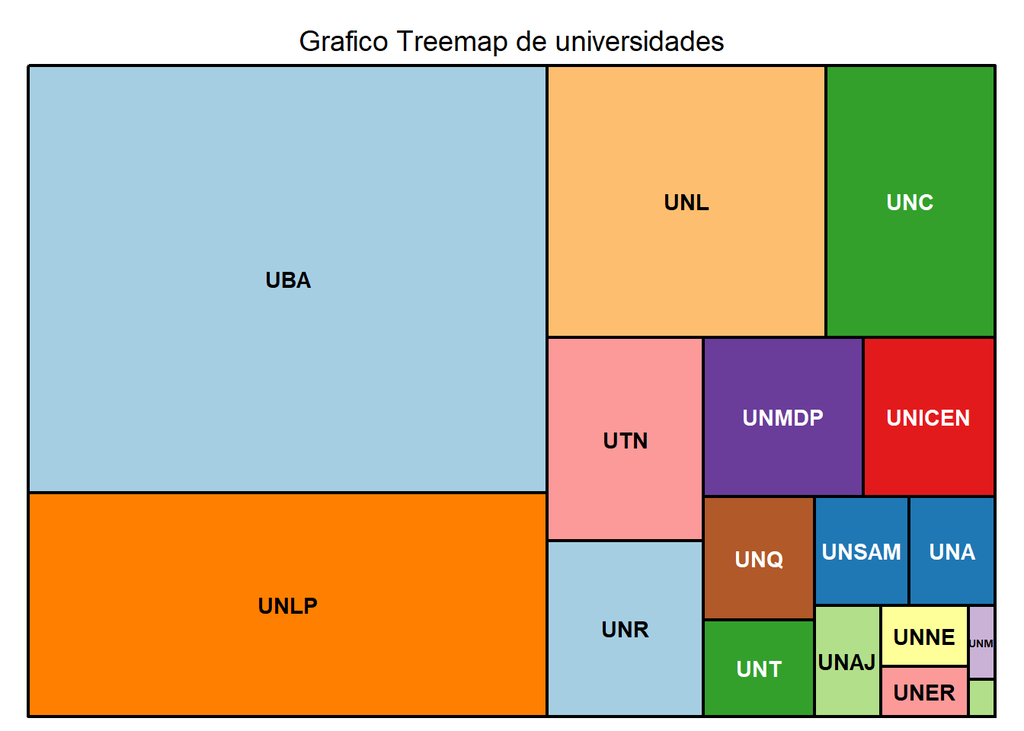

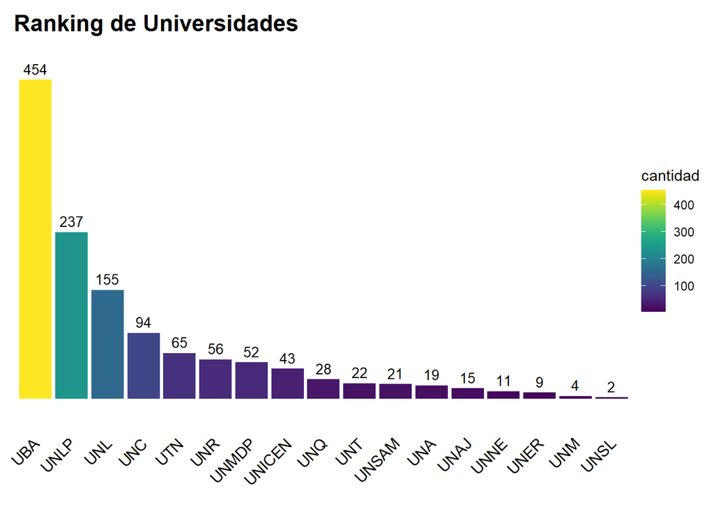

### Tablas Cruzadas

**Para:** todos los buzos  
**Incluye:** COLOR y TALLE  
**No incluye:** capybol

#### Valores absolutos

| color | L | S | VI | M |
| --- | --- | --- | --- | --- |
| BLANCO | 2 | 5 | 2 | 0 |
| CELESTE | 0 | 1 | 2 | 1 |
| CREMITA | 151 | 152 | 179 | 158 |
| FRANCIA | 0 | 2 | 3 | 3 |
| INGLES | 4 | 7 | 15 | 5 |
| LILA | 1 | 8 | 3 | 5 |
| MELANGE | 0 | 4 | 2 | 1 |
| NEGRO | 6 | 2 | 10 | 9 |
| PETROLEO | 215 | 181 | 179 | 214 |
| NA | 10 | 8 | 6 | 10 |

#### Valores porcentuales en base a las filas

| color | L | S | VI | M |
| --- | --- | --- | --- | --- |
| BLANCO | 22% | 56% | 22% | 0% |
| CELESTE | 0% | 25% | 50% | 25% |
| CREMITA | 24% | 24% | 28% | 25% |
| FRANCIA | 0% | 25% | 38% | 38% |
| INGLES | 13% | 23% | 48% | 16% |
| LILA | 6% | 47% | 18% | 29% |
| MELANGE | 0% | 57% | 29% | 14% |
| NEGRO | 22% | 7% | 37% | 33% |
| PETROLEO | 27% | 23% | 23% | 27% |
| NA | 29% | 24% | 18% | 29% |

## **PRODUCCIÓN**

### Calculadora de tela

**Aclaración:** la version actual de la calculadora de tela no calcula la tela para buzos de HP

#### Calculadora simple de cantidades

| color | cantidad | Kg | rollos |
| --- | --- | --- | --- |
| PETROLEO | 750 | 525.0 | 23.86 |
| CREMITA | 603 | 422.1 | 19.19 |
| NA | 34 | 23.8 | 1.08 |
| INGLES | 31 | 21.7 | 0.99 |
| NEGRO | 25 | 17.5 | 0.80 |
| LILA | 17 | 11.9 | 0.54 |
| BLANCO | 8 | 5.6 | 0.25 |
| FRANCIA | 8 | 5.6 | 0.25 |
| MELANGE | 7 | 4.9 | 0.22 |
| CELESTE | 4 | 2.8 | 0.13 |

#### Calculadora completa

**Parametros:**

| color | cantidad | Kg | rollos | costoT | rib | costoR | costoF |
| --- | --- | --- | --- | --- | --- | --- | --- |
| PETROLEO | 750 | 525.0 | 23.86 | 5250000 | 105.00 | 1342950 | 6592950 |
| CREMITA | 603 | 422.1 | 19.19 | 4221000 | 84.42 | 1079732 | 5300732 |
| NA | 34 | 23.8 | 1.08 | 238000 | 4.76 | 60880 | 298880 |
| INGLES | 31 | 21.7 | 0.99 | 217000 | 4.34 | 55509 | 272509 |
| NEGRO | 25 | 17.5 | 0.80 | 175000 | 3.50 | 44765 | 219765 |
| LILA | 17 | 11.9 | 0.54 | 119000 | 2.38 | 30440 | 149440 |
| BLANCO | 8 | 5.6 | 0.25 | 56000 | 1.12 | 14325 | 70325 |
| FRANCIA | 8 | 5.6 | 0.25 | 56000 | 1.12 | 14325 | 70325 |
| MELANGE | 7 | 4.9 | 0.22 | 49000 | 0.98 | 12534 | 61534 |
| CELESTE | 4 | 2.8 | 0.13 | 28000 | 0.56 | 7162 | 35162 |

### Listas para producción

#### Listado para producción version 1

| capybol | talle | color | cantidad |
| --- | --- | --- | --- |
| CAPUCHA | L | CREMITA | 25 |
| CAPUCHA | L | LILA | 1 |
| CAPUCHA | L | NEGRO | 3 |
| CAPUCHA | L | PETROLEO | 56 |
| CAPUCHA | L | NA | 3 |
| CAPUCHA | M | CELESTE | 1 |
| CAPUCHA | M | CREMITA | 32 |
| CAPUCHA | M | INGLES | 1 |
| CAPUCHA | M | LILA | 1 |
| CAPUCHA | M | NEGRO | 3 |
| CAPUCHA | M | PETROLEO | 51 |
| CAPUCHA | M | NA | 2 |
| CAPUCHA | S | BLANCO | 1 |
| CAPUCHA | S | CELESTE | 1 |
| CAPUCHA | S | CREMITA | 20 |
| CAPUCHA | S | INGLES | 2 |
| CAPUCHA | S | LILA | 4 |
| CAPUCHA | S | MELANGE | 1 |
| CAPUCHA | S | NEGRO | 1 |
| CAPUCHA | S | PETROLEO | 42 |
| CAPUCHA | S | NA | 1 |
| CAPUCHA | VI | NA | 1 |
| NO | L | BLANCO | 2 |
| NO | L | CREMITA | 126 |
| NO | L | INGLES | 4 |
| NO | L | NEGRO | 3 |
| NO | L | PETROLEO | 159 |
| NO | L | NA | 7 |
| NO | M | CREMITA | 126 |
| NO | M | FRANCIA | 3 |
| NO | M | INGLES | 4 |
| NO | M | LILA | 4 |
| NO | M | MELANGE | 1 |
| NO | M | NEGRO | 6 |
| NO | M | PETROLEO | 163 |
| NO | M | NA | 8 |
| NO | S | BLANCO | 4 |
| NO | S | CREMITA | 132 |
| NO | S | FRANCIA | 2 |
| NO | S | INGLES | 5 |
| NO | S | LILA | 4 |
| NO | S | MELANGE | 3 |
| NO | S | NEGRO | 1 |
| NO | S | PETROLEO | 139 |
| NO | S | NA | 7 |
| NO | VI | BLANCO | 2 |
| NO | VI | CELESTE | 2 |
| NO | VI | CREMITA | 179 |
| NO | VI | FRANCIA | 3 |
| NO | VI | INGLES | 15 |
| NO | VI | LILA | 3 |
| NO | VI | MELANGE | 2 |
| NO | VI | NEGRO | 10 |
| NO | VI | PETROLEO | 179 |
| NO | VI | NA | 5 |

#### Listado para producción version 2

| color | talle | CAPUCHA | NO |
| --- | --- | --- | --- |
| BLANCO | L | NA | 2 |
| BLANCO | S | 1 | 4 |
| BLANCO | VI | NA | 2 |
| CELESTE | M | 1 | NA |
| CELESTE | S | 1 | NA |
| CELESTE | VI | NA | 2 |
| CREMITA | L | 25 | 126 |
| CREMITA | M | 32 | 126 |
| CREMITA | S | 20 | 132 |
| CREMITA | VI | NA | 179 |
| FRANCIA | M | NA | 3 |
| FRANCIA | S | NA | 2 |
| FRANCIA | VI | NA | 3 |
| INGLES | L | NA | 4 |
| INGLES | M | 1 | 4 |
| INGLES | S | 2 | 5 |
| INGLES | VI | NA | 15 |
| LILA | L | 1 | NA |
| LILA | M | 1 | 4 |
| LILA | S | 4 | 4 |
| LILA | VI | NA | 3 |
| MELANGE | M | NA | 1 |
| MELANGE | S | 1 | 3 |
| MELANGE | VI | NA | 2 |
| NEGRO | L | 3 | 3 |
| NEGRO | M | 3 | 6 |
| NEGRO | S | 1 | 1 |
| NEGRO | VI | NA | 10 |
| PETROLEO | L | 56 | 159 |
| PETROLEO | M | 51 | 163 |
| PETROLEO | S | 42 | 139 |
| PETROLEO | VI | NA | 179 |
| NA | L | 3 | 7 |
| NA | M | 2 | 8 |
| NA | S | 1 | 7 |
| NA | VI | 1 | 5 |

#### Listado para producción version 3

| color | Sin capucha y bolsillo L | Sin capucha y bolsillo M | Sin capucha y bolsillo S | Sin capucha y bolsillo VI | con Capucha y bolsillo l | con Capucha y bolsillo m | con Capucha y bolsillo s |
| --- | --- | --- | --- | --- | --- | --- | --- |
| BLANCO | 2 | NA | 4 | 2 | NA | NA | 1 |
| CREMITA | 126 | 126 | 132 | 179 | 25 | 32 | 20 |
| INGLES | 4 | 4 | 5 | 15 | NA | 1 | 2 |
| NEGRO | 3 | 6 | 1 | 10 | 3 | 3 | 1 |
| PETROLEO | 159 | 163 | 139 | 179 | 56 | 51 | 42 |
| NA | 7 | 8 | 7 | 5 | 3 | 2 | 1 |
| FRANCIA | NA | 3 | 2 | 3 | NA | NA | NA |
| LILA | NA | 4 | 4 | 3 | 1 | 1 | 4 |
| MELANGE | NA | 1 | 3 | 2 | NA | NA | 1 |
| CELESTE | NA | NA | NA | 2 | NA | 1 | 1 |

#### Listado para produccion de HP

|  | L | M | S |
| --- | --- | --- | --- |
| GRY | 0 | 1 | 2 |
| HUF | 1 | 0 | 1 |
| RAV | 0 | 1 | 2 |
| SLY | 2 | 2 | 0 |

#### Hilo

| hilo | n_buzos |
| --- | --- |
| azul_petroleo | 237 |
| color_uni | 307 |
| cremita | 741 |
| metalizado | 41 |
| NA | 228 |

## **ANALISIS ESPACIAL**

### Provincias

**Tabla**

| provincia | pedidos |
| --- | --- |
| gran buenos aires | 448 |
| capital federal | 425 |
| buenos aires | 328 |
| santa fe | 82 |
| cordoba | 60 |
| entre rios | 22 |
| neuquen | 22 |
| rio negro | 18 |
| mendoza | 15 |
| tucuman | 15 |
| chaco | 8 |
| chubut | 6 |
| salta | 6 |
| corrientes | 5 |
| la pampa | 5 |
| tierra del fuego | 5 |
| santa cruz | 4 |
| santiago del estero | 4 |
| la rioja | 3 |
| san luis | 2 |
| catamarca | 1 |
| formosa | 1 |
| jujuy | 1 |
| misiones | 1 |

**Mapa**

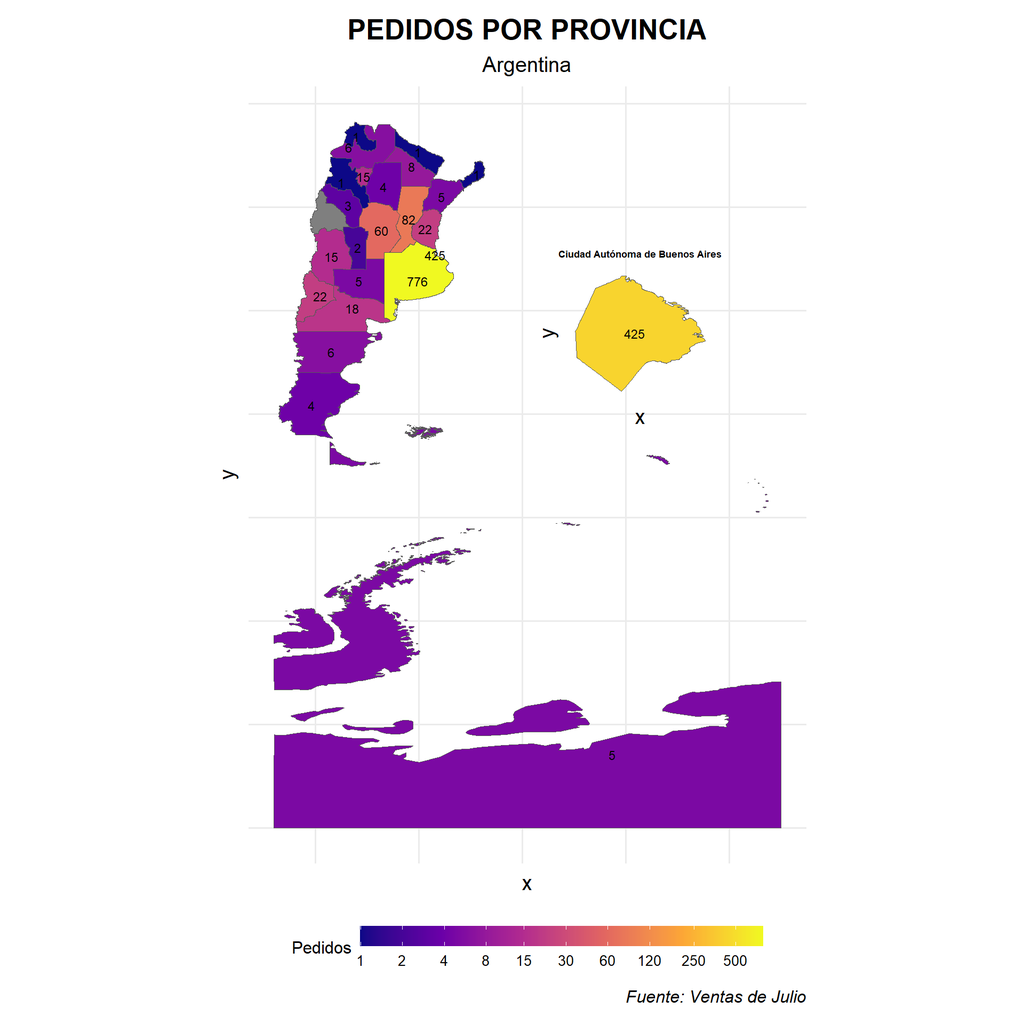

### Partidos de Buenos Aires

**Tabla**

| indice | departamen | pedidos |
| --- | --- | --- |
| 1 | la plata | 164 |
| 2 | general pueyrredon | 45 |
| 3 | la matanza | 43 |
| 4 | lomas de zamora | 33 |
| 5 | quilmes | 30 |
| 6 | avellaneda | 27 |
| 7 | lanus | 26 |
| 8 | almirante brown | 25 |
| 9 | vicente lopez | 25 |
| 10 | esteban echeverria | 21 |
| 11 | florencio varela | 20 |
| 12 | berazategui | 18 |
| 13 | general san martin | 17 |
| 14 | olavarria | 17 |
| 15 | san isidro | 17 |
| 16 | moreno | 15 |
| 17 |  | 13 |
| 18 | merlo | 12 |
| 19 | san fernando | 12 |
| 20 | san miguel | 12 |
| 21 | ezeiza | 10 |
| 22 | moron | 10 |
| 23 | tandil | 9 |
| 24 | tres de febrero | 9 |
| 25 | ituzaingo | 8 |
| 26 | tigre | 8 |
| 27 | bahia blanca | 7 |
| 28 | malvinas argentinas | 7 |
| 29 | ensenada | 6 |
| 30 | lobos | 5 |

[output cut: 60 more lines]

**Mapa**

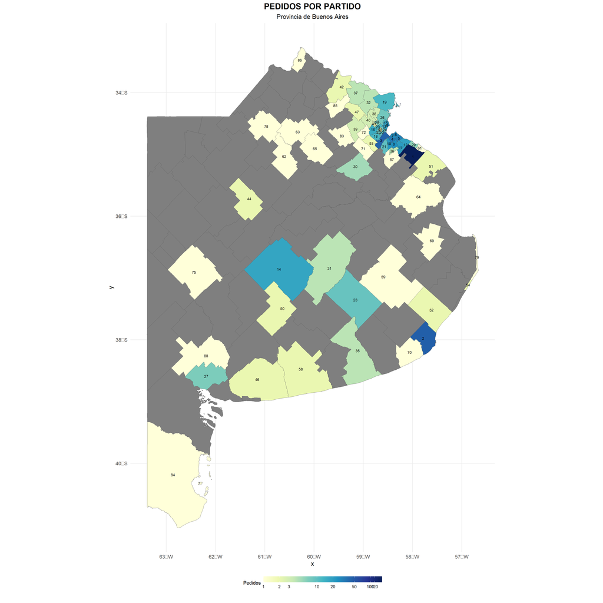

### Moto-mensajería

El costo de Motomensajeria es **805,500** por un total de **224** envios.

## **CONTABILIDAD**

#### Matrices

El costo de Matrices es **502.500**.

#### Sueldos fijos

El costo de sueldos fijos es **8.640.000**.

#### Costos fijos

El costo fijo sin sueldos es **2.026.232**.

#### Costo de costura

Tabla de COSTURA

| capybol | Información cantidad | Información julio | Información costo_costura |
| --- | --- | --- | --- |
| CAPUCHA | 253 | 1700 | 430100 |
| NO | 1313 | 1500 | 1969500 |

El costo final de costura es **2.399.600**.

#### Costo de tela

El costo de tela es **13.071.622**.

#### Costo de bordado

siendo el costo promedio de un bordado **5500** con **1566** buzos vendidos, el costo final de bordado asciende a **8.613.000**

#### Costo de packing

siendo el costo promedio de un packing **350** con **1566** buzos vendidos, el costo final de bordado asciende a **548.100**

### Balance general

#### **Tabla de balance**

| cuenta | julio | porcent_jul |
| --- | --- | --- |
| ingresos | 62199275 | 100.0 |
| correoarg | 4169975 | 6.7 |
| motomensajeria | 805500 | 1.3 |
| costo_matrices | 502500 | 0.8 |
| costo_costura | 2399600 | 3.9 |
| total_costo_fijo | 2026232 | 3.3 |
| total_sueldos_fijos | 8640000 | 13.9 |
| costo_tela | 13071622 | 21.0 |
| costo_bordado | 8613000 | 13.8 |
| costo_packing | 548100 | 0.9 |
| costos_totales | 40776529 | 65.6 |
| resultado_primario | 21422746 | 34.4 |

#### **Graficos**

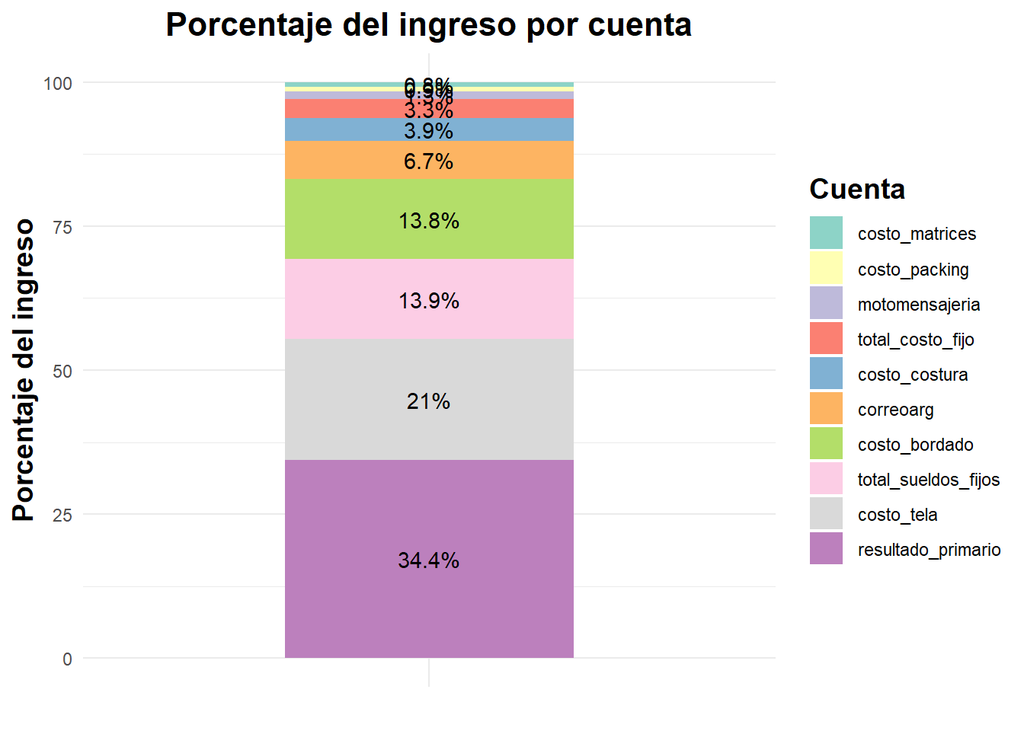

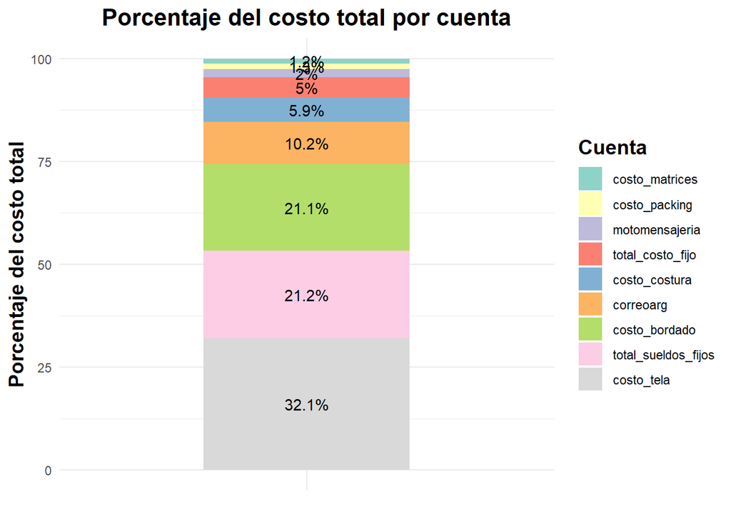

### Balance “fino”

**se recalcula el balance pero se quitan cuentas que no hacen al costo del producto: motomensajeria,correo argentino,matrices**

**Tambien se suma una columna que nos muestra como se distribuyen estos costos en el precio unitario de un buzo**

| cuenta | julio | porcent_jul | unitario |
| --- | --- | --- | --- |
| ingresos | 56721300 | 100.0 | 36220 |
| costo_costura | 2399600 | 4.2 | 1532 |
| total_costo_fijo | 2026232 | 3.6 | 1294 |
| total_sueldos_fijos | 8640000 | 15.2 | 5517 |
| costo_tela | 13071622 | 23.0 | 8347 |
| costo_bordado | 8613000 | 15.2 | 5500 |
| costo_packing | 548100 | 1.0 | 350 |
| costos_totales_BUZO | 35298554 | 62.2 | 22541 |
| resultado_primario | 21422746 | 37.8 | 13680 |

#### **Graficos**

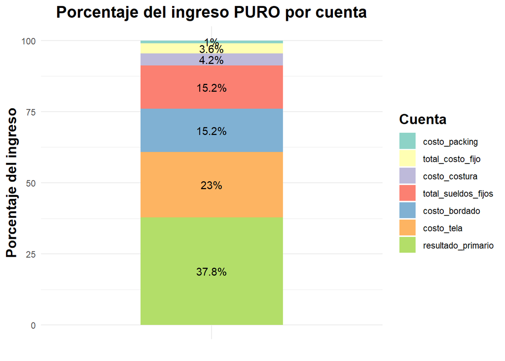

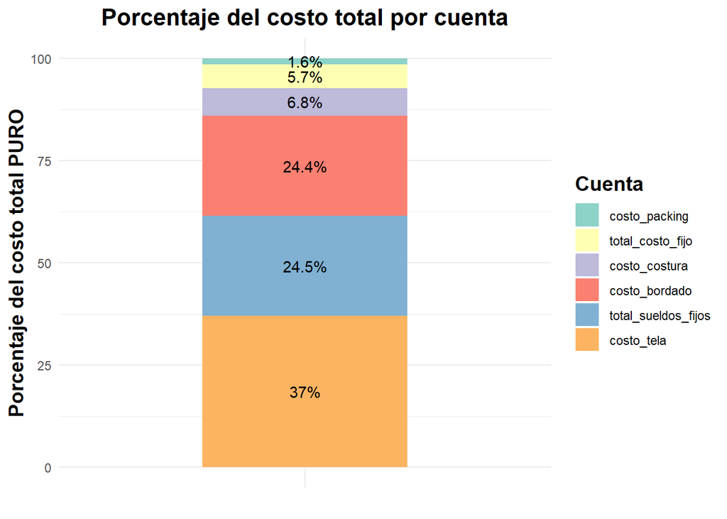

## **INSIGHTS**

- **Principales variables de ajuste**

El costo de la tela puede ser optimizado por la vía del stockeo o pago anticipado frente a futuras subas. Este estudio permite saber cuánta tela y de qué colores conviene stockearse.

El Correo Argentino supone una de las vías de ajuste (y oportunidad) más interesantes, ya que desarrollar una cadena de entrega de pedidos propia cerca del área de la empresa puede llevar a la reducción del costo que paga el cliente por el envío y/o la captación de mayores recursos propios y nuevos puestos de trabajo.

El costo de costura es un costo importante dentro de la estructura de costos y puede ser optimizado delegando esa fase en más talleres, lo cual podría tener como ganancia aún mayor, la agilización en los plazos de costura.

El costo del packing es de los más bajos de la empresa, pero también es el más fácil de optimizar estando atentos a nuevos proveedores.

- **Motomensajería**

Resulta imperioso medir el punto crítico en el cual el número de pedidos por motomensajería y la concentración de los mismos se vuelve inabarcable por el repartidor, para pensar en opciones de depósito en CABA, incorporación de más personal o nuevas alternativas.

- **Provincias**

No se han vendido pedidos a la provincia de San Juan.  
¿Hay un producto de interés para San Juan que esté sin explotar?

- **Producto HP**

El producto HP está en claro declive en comparación con otros, sin embargo, supo ser un éxito de ventas, por lo cual, en primer lugar, debe pensarse en la colocación del mismo en nuevos mercados, sea por la vía de la exportación o la colocación en lugares estratégicos.

### Propuestas

- **Creación de primeros KPIs:**

Los KPIs **(key performance indicators)** son indicadores clave de rendimiento que se utilizan para evaluar el éxito de las acciones y/o procesos en la medida en que estos contribuyen a la consecución de los objetivos, para determinar si están dando los frutos esperados o es necesario realizar correcciones.

Se sugieren algunos KPIs iniciales para comenzar a ser medidos desde la próxima entrega:

**SR (Savings Rate):** Ahorro/resultado primario

Se propone medir tanda por tanda la parte del resultado primario que fue destinada al ahorro en la tanda anterior. De este modo se pueden verificar los avances y retrocesos en términos de los objetivos de inversión de la empresa.

**SDI (Spatial Density Indicator):**

Indicador para medir el grado de concentración de los pedidos en el AMBA, en comparación con el resto del país. Útil para desarrollar campañas de marketing pensadas para una mayor penetración territorial en las distintas provincias.

**TD (Topic Distribution):**

La variedad de diseños posibles y de distintas temáticas es un punto positivo de la marca. Sin embargo, al no existir denominaciones estandarizadas para los diseños ni agrupamiento por grandes “tópicos” de estos, no es posible trackear el ascenso o declive del interés sobre estos tópicos a través del tiempo. Un trabajo a largo plazo es el desarrollo de un indicador que pueda medir la distribución de los tópicos de los productos.